# Escolas com Ensino Médio em Porto Velho e Cuiabá

Author

Michele Caramigo

Published

February 1, 2024

## Objetivo

Para identificar as escolas do ensino médio nos municípios Porto Velho e Cuiabá foi utilizado o pacote geobr para então visualizar as escolas por nível governamental (government_level) que esses municipios possuem.

## Código utilizado

O pacote geobr foi carregado e através da função list_geobr,e identifica-se o comando para conhecer os dados sobre as escolas, read_schools.

```
                      function
1               `read_country`
2                `read_region`
3                 `read_state`
4           `read_meso_region`
5          `read_micro_region`
6   `read_intermediate_region`
7      `read_immediate_region`
8          `read_municipality`
9        `read_municipal_seat`
10       `read_weighting_area`
11         `read_census_tract`
12     `read_statistical_grid`
13           `read_metro_area`
14           `read_urban_area`
```

[output cut: 97 more lines]

[output not shown]

[output cut: 4275 more lines]

[output not shown]

A função read_schools foi executada e resultado carregado no objeto “escolas”.

Após obter o conteúdo das escolas, foi utilizado filtro por municipio, Porto Velho e Cuiabá.

E como o objetivo é a visualização das escolas que possuem ensino médio nesses municípios o comando seguinte é para fazer a busca das escolas com Ensino Médio.

Primeiramente em Porto Velho e abaixo em Cuiabá.

Por último apresentamos a visualização gráfica a cada município, Porto Velho e Cuiabá com as escolas que tem Ensino Médio por classificação da escola: Pública(Estadual ou Federal) ou Privada e número de matrículas.

Município: Porto Velho

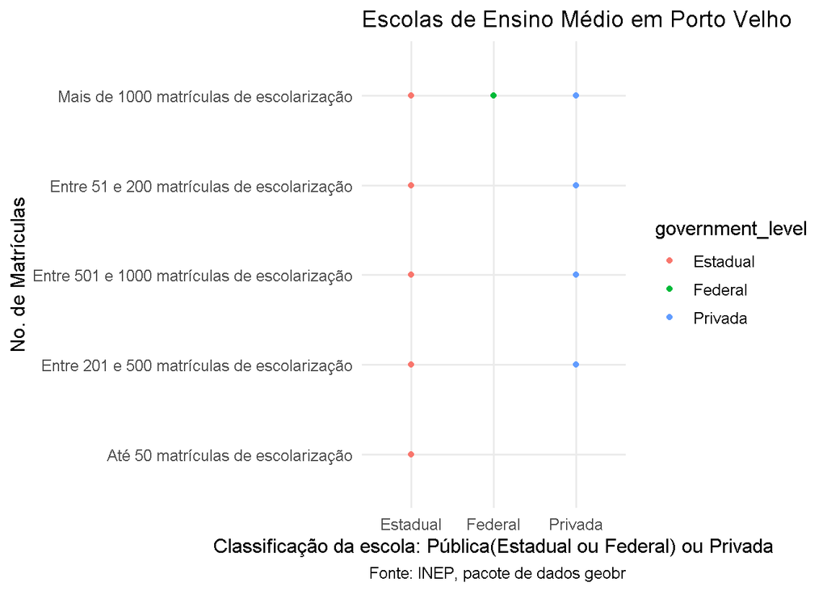

Município: Cuiabá

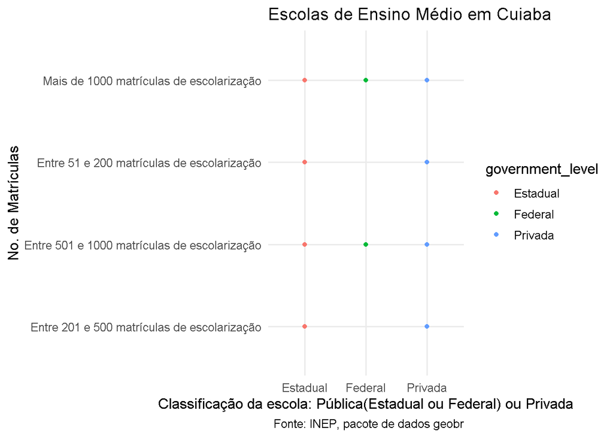

## Conclusão

Conseguimos visualizar a distribuição das escolas que possui ensino médio dos municípios estudados por nivel governamental(government_level).